# RepData

Ekaterina

14 December 2017

# Personal movement data analysis

This Assignment reports answers on a list of questions on the data about personal movement using activity monitoring devices.

## Loading and preprocessing the data

- Firstly, we retrieve the data from the link provided.

```r
library(stringr)
setwd('C:/Users/petrova/Desktop/temp/Represearch')
download.file('https://d396qusza40orc.cloudfront.net/repdata%2Fdata%2Factivity.zip','Activity.zip')
unzip('Activity.zip')
actdata <- read.csv('activity.csv', sep = ',')
```

- Now a little bit of ‘cleaning’ is performed. We add additional column ‘time’ for subsequent grouping

```r
actdata$datatime <- as.POSIXct(strptime(paste(actdata$date, str_pad(actdata$interval,4,pad = "0")),"%Y-%m-%d %H%M"))
actdata$time <- as.POSIXct(strptime(paste('1900-10-01', str_pad(actdata$interval,4,pad = "0")),"%Y-%m-%d %H%M"))
head(actdata, 3)
```

```
##   steps       date interval            datatime                time
## 1    NA 2012-10-01        0 2012-10-01 00:00:00 1900-10-01 00:00:00
## 2    NA 2012-10-01        5 2012-10-01 00:05:00 1900-10-01 00:05:00
## 3    NA 2012-10-01       10 2012-10-01 00:10:00 1900-10-01 00:10:00
```

## What is mean total number of steps taken per day

- Let’s see the histogram of the total number of steps taken each day

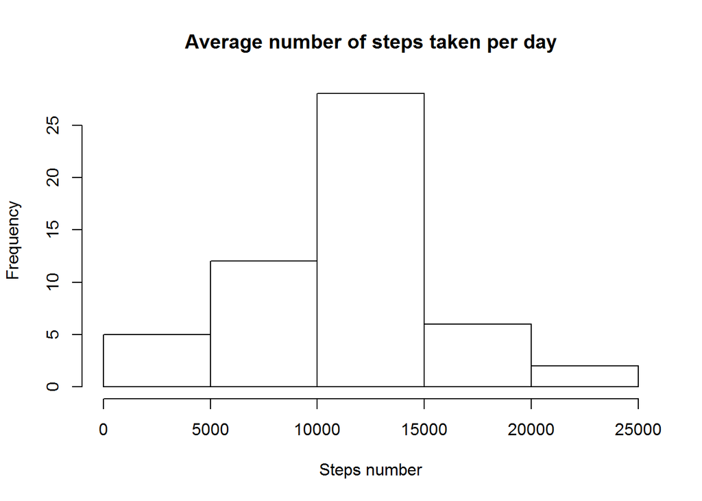

```r
library(data.table)
actdata <- as.data.table(actdata)
gractdata <- actdata[,list(steps = sum(steps)), by=list(date)]
hist( gractdata$steps, xlab = 'Steps number', main = 'Average number of steps taken per day')
```

- And check the mean and median of the total number of steps taken per day

```r
mean(gractdata$steps, na.rm = TRUE)
```

```
## [1] 10766.19
```

```r
median(gractdata$steps, na.rm = TRUE)
```

```
## [1] 10765
```

## What is the average daily activity pattern?

- Here is a plot of average number of steps taken, averaged across all days (y-axis)

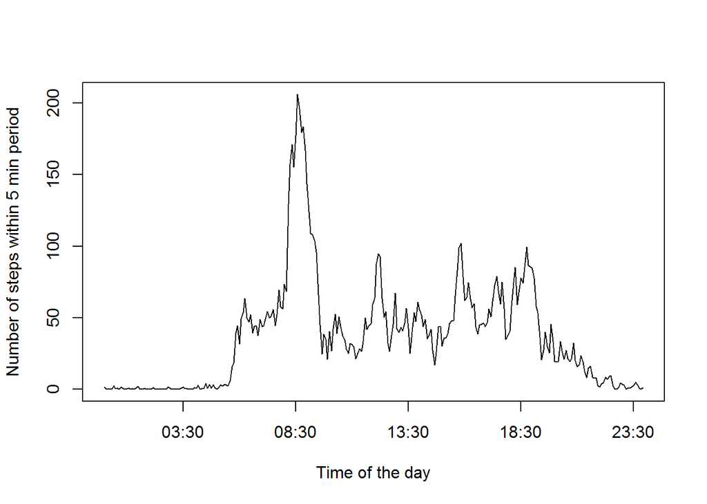

```r
timedata <- actdata[,list(steps = mean(steps, na.rm = TRUE)), by=list(time)]
plot(timedata$time, timedata$steps, type='l', xlab='Time of the day', ylab = 'Number of steps within 5 min period')
```

- Interval of the day which contains the maximum number of steps:

```r
format(timedata$time[timedata$steps == max(timedata$steps)], "%H:%M")
```

```
## [1] "08:35"
```

## Imputing missing values

- Total number of missing values in the dataset

```r
sum(is.na(actdata[, steps]))
```

```
## [1] 2304
```

- Strategy for filling in all of the missing values in the dataset We will use average result or this time of the day
- Create a new dataset that is equal to the original dataset but with the missing data filled in

```r
actdataclear <- merge(actdata, timedata, all.x=TRUE, by = c('time'))
actdataclear$steps <- ifelse(is.na(actdataclear$steps.x), actdataclear$steps.y, actdataclear$steps.x)
actdataclear$steps.x <- NULL
actdataclear$steps.y <- NULL
gractdataClear <- actdataclear[,list(steps = sum(steps)), by=list(date)]
```

- Histogram of the total number of steps taken each day:

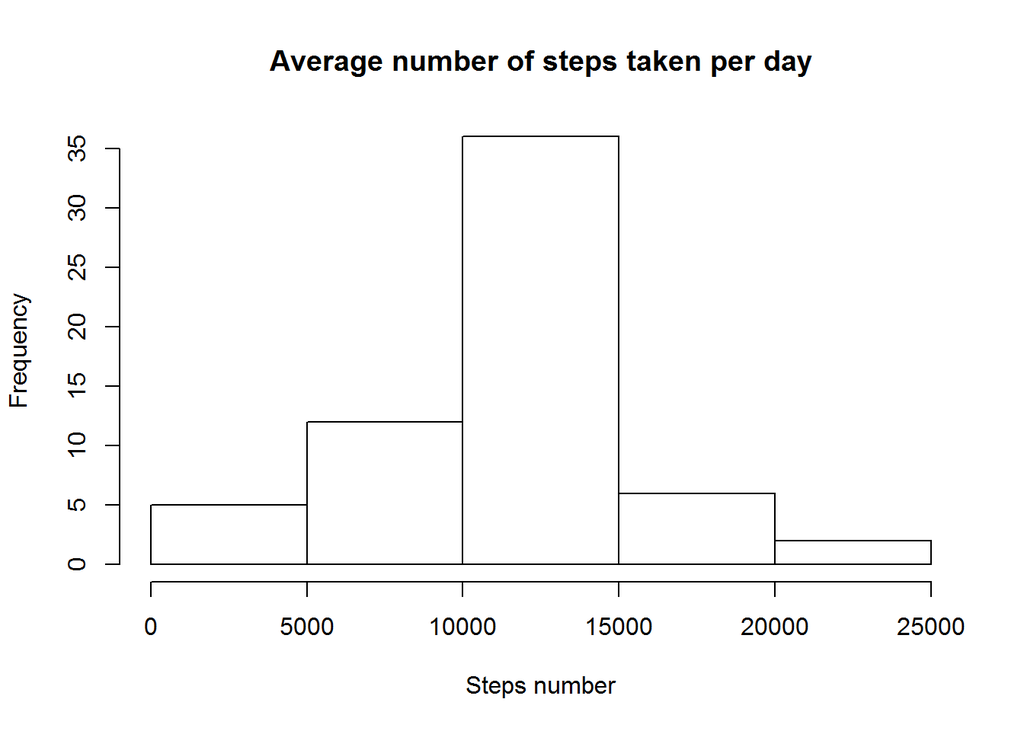

```r
hist( gractdataClear$steps, xlab = 'Steps number', main = 'Average number of steps taken per day')
```

- Mean and median total number of steps taken per day:

```r
mean(gractdataClear$steps)
```

```
## [1] 10766.19
```

```r
median(gractdataClear$steps)
```

```
## [1] 10766.19
```

- Note that the mean and median are happened to be the same as missing data was probably spread evenly between all times of the day

## Are there differences in activity patterns between weekdays and weekends?

```r
Sys.setlocale("LC_ALL","English")
```

```
## [1] "LC_COLLATE=English_United States.1252;LC_CTYPE=English_United States.1252;LC_MONETARY=English_United States.1252;LC_NUMERIC=C;LC_TIME=English_United States.1252"
```

```r
actdataclear$weekdays <- as.factor(ifelse(weekdays(as.Date(actdataclear$date)) %in% c("Friday", "Saturday"), 'weekend', 'weekday'))
```

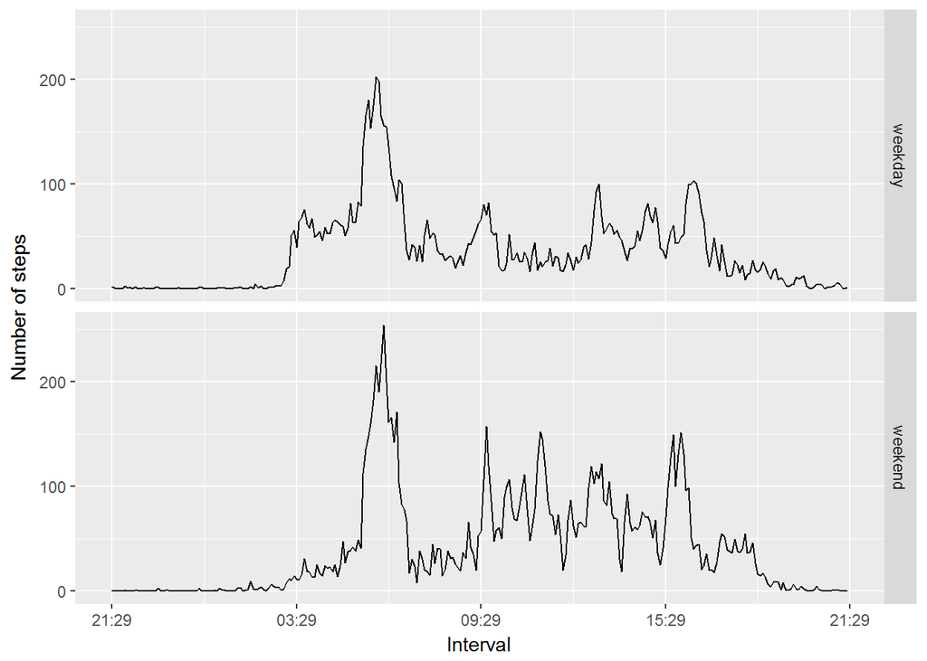

```r
timedataClear <- actdataclear[,list(steps = mean(steps, na.rm = TRUE)), by=list(time, weekdays)]
library(ggplot2)
library(scales)
ggplot(data=timedataClear, aes(x=time, y=steps)) + geom_line() + facet_grid(weekdays ~ .) + xlab('Interval') + ylab('Number of steps')+ scale_x_datetime(labels = date_format('%H:%M'))
```